# week-5

Rupa Shrestha

2024-09-26

```r
library(readxl)
data_set <- read_excel("D:/Webster University/Assignments/Analytics Programming/week-5/Data_HW5.xlsx")
```

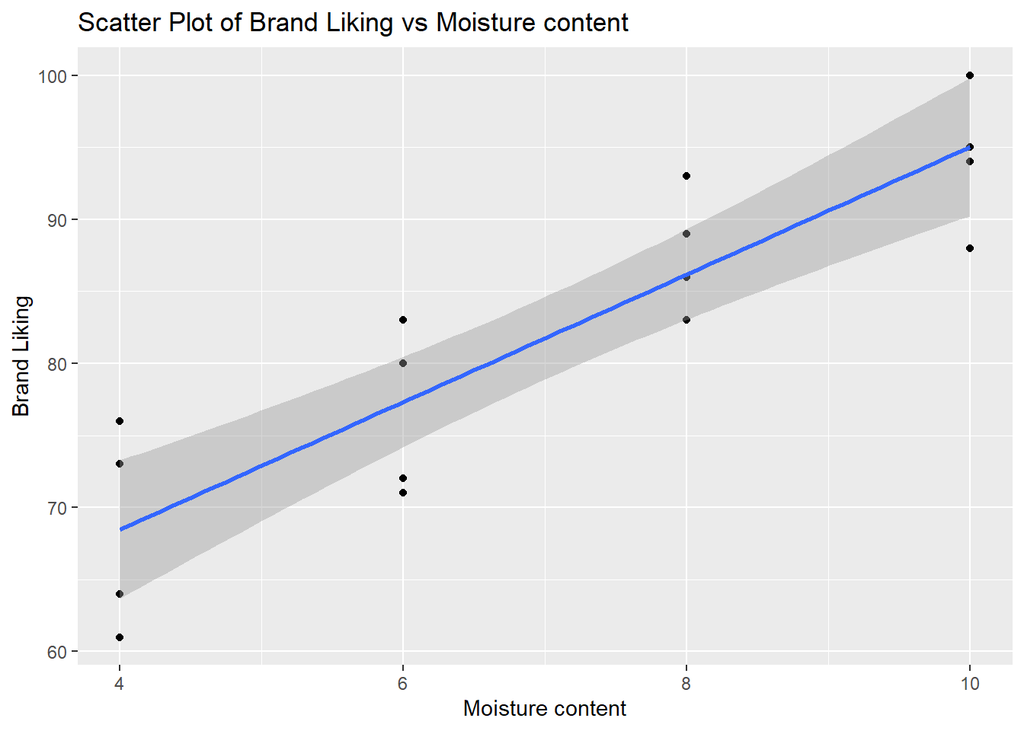

```r
#1) a) Obtain the scatter plot matrix and the correlation matrix. What information do these diagnostic aids provide here?

#SOLUTION
library(ggplot2)
library(api2lm)
library(lmSubsets)
library(olsrr)
ggplot(data=data_set, mapping = aes(x = X1, y = Y)) + geom_point() + geom_smooth(method = "lm") + labs(
    title = "Scatter Plot of Brand Liking vs Moisture content",
    x = "Moisture content",
    y = "Brand Liking"
  )
```

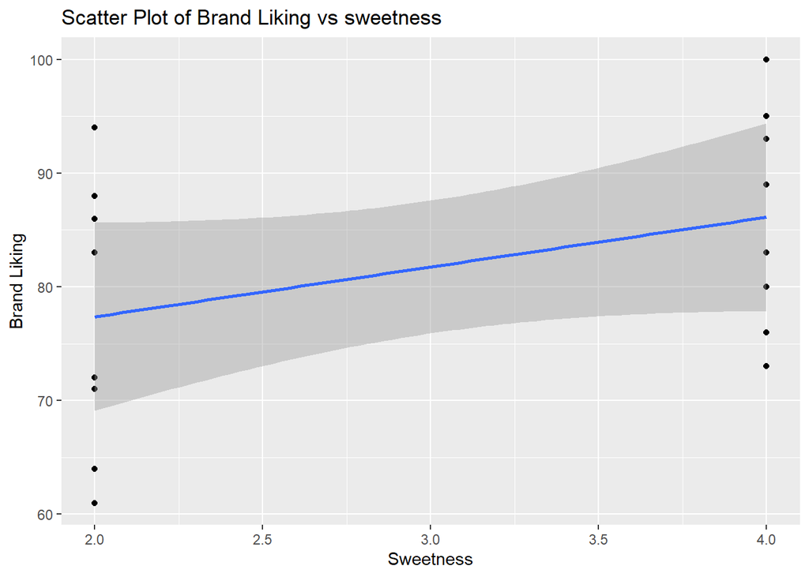

```r
ggplot(data=data_set, mapping = aes(x = X2, y = Y)) + geom_point() + geom_smooth(method = "lm") + labs(
    title = "Scatter Plot of Brand Liking vs sweetness",
    x = "Sweetness",
    y = "Brand Liking"
  )
```

```r
cor(data_set)
```

```
##            Y        X1        X2
## Y  1.0000000 0.8923929 0.3945807
## X1 0.8923929 1.0000000 0.0000000
## X2 0.3945807 0.0000000 1.0000000
```

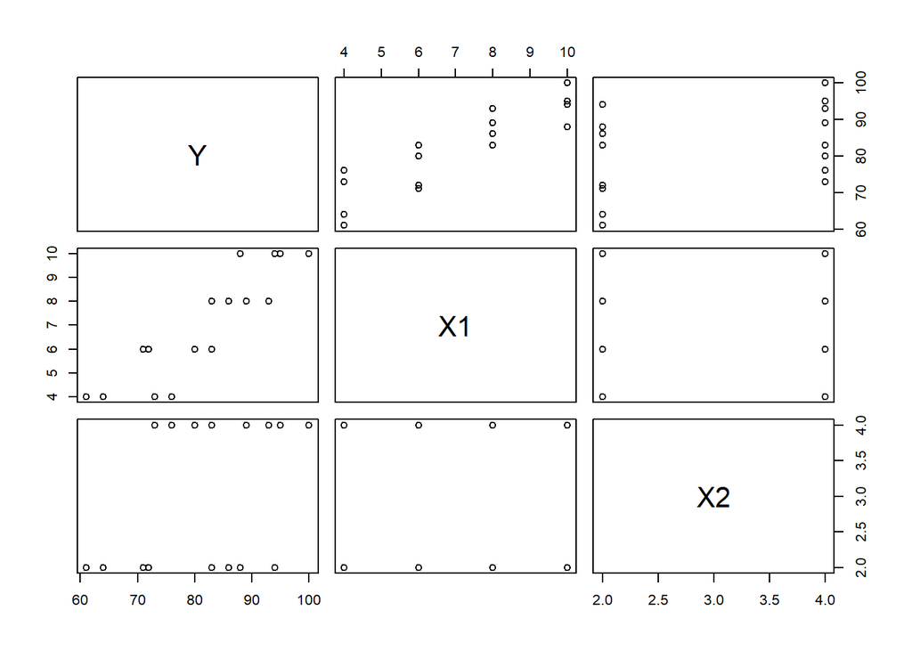

```r
#pairwise correlation
 pairs(Y ~ X1+X2, data_set)
```

## The first scatter plot shows a positive linear relationship between Y and X1. The regression line fits the data reasonably well.

## The second scatter plot shows a slight positive relationship between X2 and Y, with the blue line indicating the trend and the grey area showing the confidence range.

```r
# b. Fit the regression model to the data. State the estimated regression function. Interpret b1.

#SOLUTION
# Fit the regression model
model <- lm(Y ~ X1 + X2, data = data_set)

# Display the summary of the model
summary(model)
```

```
##
## Call:
## lm(formula = Y ~ X1 + X2, data = data_set)
##
## Residuals:
##    Min     1Q Median     3Q    Max
## -4.400 -1.762  0.025  1.587  4.200
##
## Coefficients:
##             Estimate Std. Error t value Pr(>|t|)
## (Intercept)  37.6500     2.9961  12.566 1.20e-08 ***
## X1            4.4250     0.3011  14.695 1.78e-09 ***
## X2            4.3750     0.6733   6.498 2.01e-05 ***
## ---
## Signif. codes:  0 '***' 0.001 '**' 0.01 '*' 0.05 '.' 0.1 ' ' 1
##
## Residual standard error: 2.693 on 13 degrees of freedom
## Multiple R-squared:  0.9521, Adjusted R-squared:  0.9447
## F-statistic: 129.1 on 2 and 13 DF,  p-value: 2.658e-09
```

```r
# Extract coefficients
intercept <- coef(model)[1]
b1 <- coef(model)[2]
b2 <- coef(model)[3]

# Estimated regression function
#Y=β0+β1⋅X1+β2⋅X
print(paste("Estimated regression function: Y =", intercept, "+", b1, "* X1 +", b2, "* X2\n"))
```

```
## [1] "Estimated regression function: Y = 37.65 + 4.425 * X1 + 4.375 * X2\n"
```

```r
# Interpret b1
print(paste("Interpretation of b1: For a one unit increase in X1, Y is expected to increase by", b1, "units, holding X2 constant."))
```

```
## [1] "Interpretation of b1: For a one unit increase in X1, Y is expected to increase by 4.425 units, holding X2 constant."
```

#The coefficient b1 represents the change in the degree of brand liking Y for each one-unit increase in moisture content X1, holding sweetness X2 constant #For example, if b1 =3, it means that for every additional unit of moisture (assuming X1 increases by 1), the brand liking score Y increases by 3 points, regardless of the sweetness level X2.

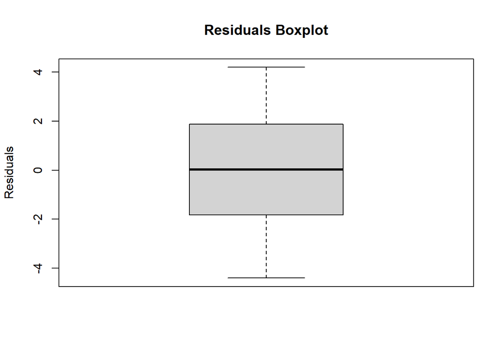

```r
# c) Obtain the residuals and prepare boxplot. What information does it provide?

#SOLUTION
residuals <- model$residuals
boxplot(residuals, main = "Residuals Boxplot", ylab = "Residuals")
```

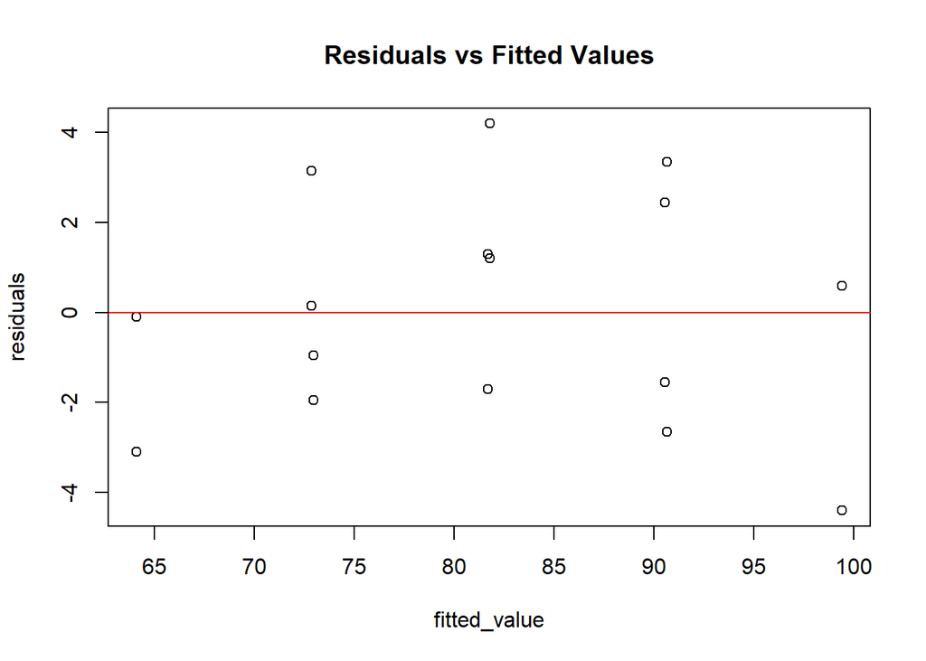

```r
# d) Plot the residuals against the fitted values, X1 and X2. Interpret them.

#SOLUTION
# Plot residuals against fitted values
fitted_value <- model$fitted.values
X1 <- data_set$X1
X2 <- data_set$X2

plot(fitted_value, residuals, main="Residuals vs Fitted Values")
abline(h=0, col="red")
```

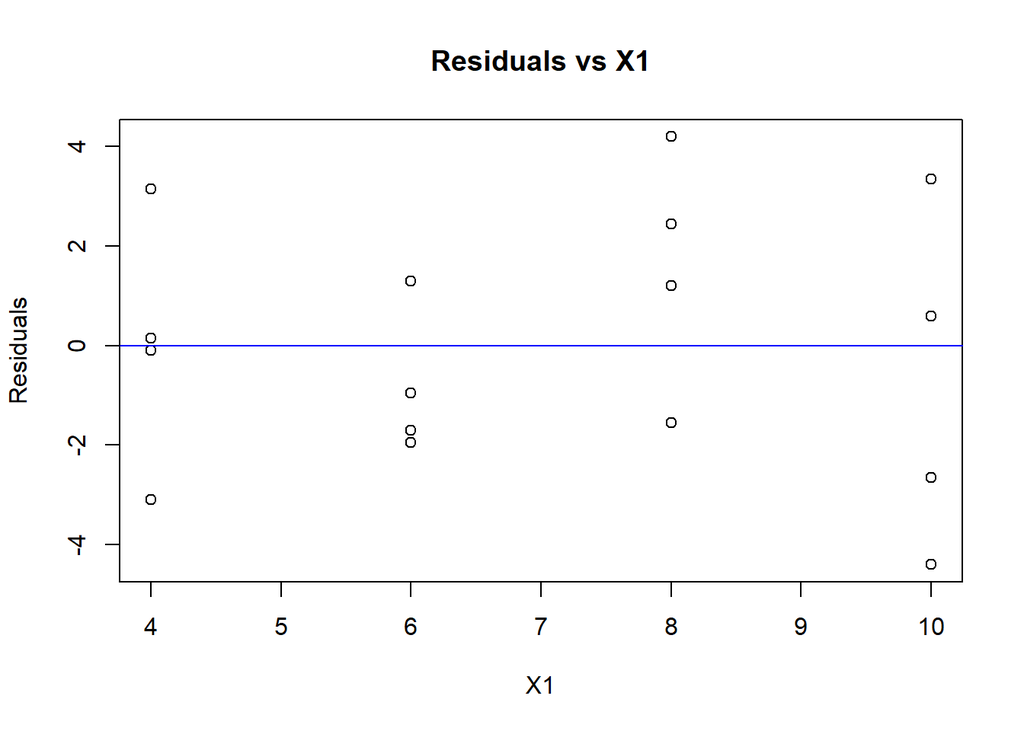

```r
# Plot residuals vs X1
plot(X1, residuals, main = "Residuals vs X1", xlab = "X1", ylab = "Residuals")
abline(h = 0, col = "blue")
```

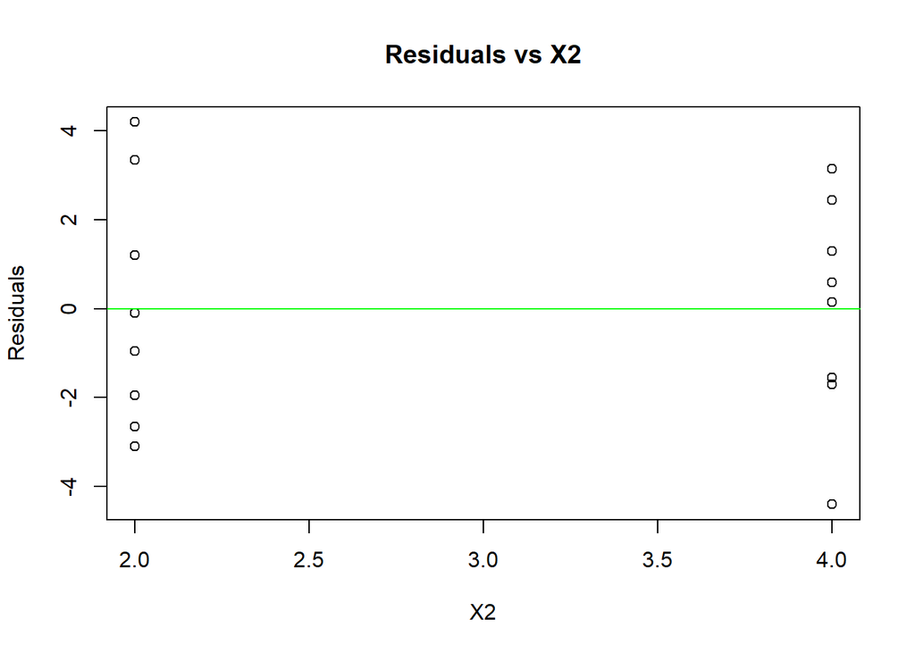

```r
# Plot residuals vs X2
plot(X2, residuals, main = "Residuals vs X2", xlab = "X2", ylab = "Residuals")
abline(h = 0, col = "green")
```

## Residuals vs Fitted Values: Residuals are randomly scattered around zero, suggesting no issues with the model’s predictions across different fitted values.

## Residuals vs X1: Shows residuals scattered around zero with no clear pattern, indicating a good fit between X1 and the model.

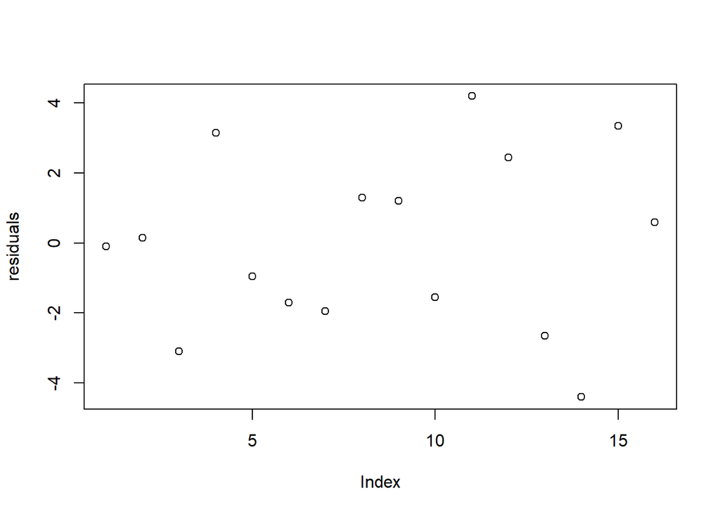

```r
#e) Prepare a normal probability plot of the residuals and obtain the test statistics. State the results.

#SOLUTION
#Normality Probability plot
plot(residuals)
```

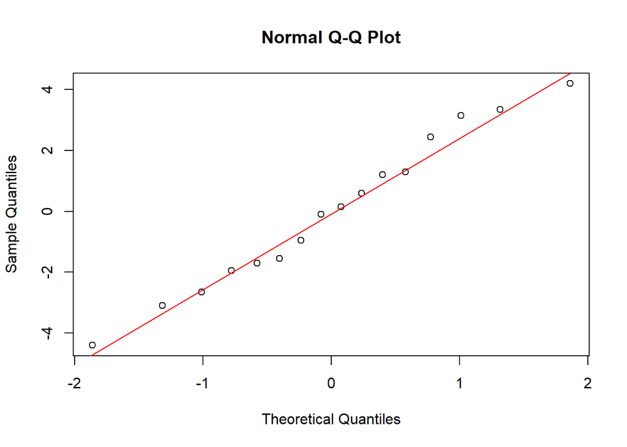

```r
qqnorm(residuals)
qqline(residuals, col = "red")
```

```r
# Shapiro-Wilk test for normality
shapiro_test <- shapiro.test(residuals)
shapiro_test
```

```
##
##  Shapiro-Wilk normality test
##
## data:  residuals
## W = 0.97585, p-value = 0.9222
```

## The points fall along the diagonal line, the residuals are normally distributed.

## Since p-value is greater than defalut value(0.05), so we fail to reject the null hypothesis. This indicates tha the residuals residuals do not significantly deviate from normality.

```r
#f) Test whether there is a regression relation, using α = .01. State the alternatives, decision rule, and conclusion. What does your test imply about β1 and β2?

#SOLUTION
anova_result <- anova(model)
anova_result
```

```
## Analysis of Variance Table
##
## Response: Y
##           Df  Sum Sq Mean Sq F value    Pr(>F)
## X1         1 1566.45 1566.45 215.947 1.778e-09 ***
## X2         1  306.25  306.25  42.219 2.011e-05 ***
## Residuals 13   94.30    7.25
## ---
## Signif. codes:  0 '***' 0.001 '**' 0.01 '*' 0.05 '.' 0.1 ' ' 1
```

## Both β1 and β2 are statistically significant, indicating that both moisture content and sweetness play important roles in predicting the degree of brand liking.

```r
#g) Calculate the coefficient of multiple determination R2. How is it interpreted here?

# SOLUTION
R_squared <- summary(model)$r.squared
print(paste("R² =", R_squared))
```

```
## [1] "R² = 0.952058973055414"
```

## R2 = 0.952059 indicates that the model explains substantial amount of the variance in brand liking, highlighting the effectiveness of moisture content and sweetness as predictors in regression model.

```r
#h) Obtain an interval estimate of E {Yx0} when X10 = 5 and X20 = 4. Use a 99 percent confidence coefficient. Interpret your interval estimate.

#SOLUTION
# New data for prediction
new_data <- data.frame(X1 = 5, X2 = 4)

# 99% confidence interval
predict(model, newdata = new_data, interval = "confidence", level = 0.99)
```

```
##      fit      lwr      upr
## 1 77.275 73.88111 80.66889
```

## The confidence inverval shows that for a product with moisture content of 5 and sweetness of 4, we can be 99% confident that the average degree of brand lking will be between apporx. 73.88 and 80.67. It helps to understand customer prefernce based on product characteristics.

```r
# i) Obtain a prediction interval for a new observation Y0(new) when X10 = 5 and X20. Use a 99 percent confidence coefficient.

#SOLUTION
# Prediction interval
prediction_interval <- predict(model, newdata = new_data, interval = "prediction", level = 0.99)
print(prediction_interval)
```

```
##      fit      lwr      upr
## 1 77.275 68.48077 86.06923
```

## We can be 99% confident that a new data of brand liking for a product with moisture content of 5 and sweetness of 4 will fall between 68.481 and 86.069.

```r
#2) The lengths of pregnancies in a small rural village are normally distributed with a mean of 265 days and a standard deviation of 15 days.
#a. In what range would you expect to find the middle 50% of most pregnancies?
#b. What proportion of pregnancies will be more than 275 days?

# SOLUTION:

mean_pregnancy <- 265
sd_pregnancy <- 15

# a. Middle 50% (Q1 and Q3)
q1 <- qnorm(0.25, mean = mean_pregnancy, sd = sd_pregnancy)
q2 <- qnorm(0.75, mean=mean_pregnancy, sd=sd_pregnancy)
print(paste("Middle 50% range of pregnancies: ",q1 , q2))
```

```
## [1] "Middle 50% range of pregnancies:  254.882653747059 275.117346252941"
```

```r
# b. Proportion of pregnancies > 275 days
prob_more_275 <- 1-pnorm(275,mean = mean_pregnancy,sd=sd_pregnancy)
print(paste("Proportion of pregnancies more than 275 days: ", prob_more_275))
```

```
## [1] "Proportion of pregnancies more than 275 days:  0.252492537546923"
```

```r
#3) A certain car model has a mean gas mileage of 34 miles per gallon (mpg) with a standard deviation 5mpg. If a car is selected at random,

#a) What is the probability that the mileage of the selected car is greater than 33 mpg?
#b) What is the probability that the mileage of the car is between 33mpg and 35mpg?

#SOLUTION

mean_gas_mileage <- 34
mileage_sd <-5

#a selected car mileage is greater than 33 mpg
prob_mileage_greater_than_33 <- 1-pnorm(33,mean=mean_gas_mileage,sd=mileage_sd)
print(paste("Probability that the mileage os selected car is greater than 33 mpg: ", prob_mileage_greater_than_33))
```

```
## [1] "Probability that the mileage os selected car is greater than 33 mpg:  0.579259709439103"
```

```r
#b mileage of the car is between 33mpg and 35 mpg
prob_mileage_btn_33_35 <- pnorm(35, mean=mean_gas_mileage, sd=mileage_sd) - pnorm(33, mean=mean_gas_mileage, sd=mileage_sd)
print(paste("Probability of mileage between 33 and 35 is: ", prob_mileage_btn_33_35))
```

```
## [1] "Probability of mileage between 33 and 35 is:  0.158519418878206"
```